# Dual-number verification — is the bottom Arabic the right page?

p.130 volume (arabic, bottom) was 32 → 130

TOP

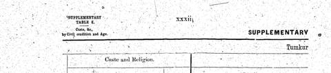

BOTTOM

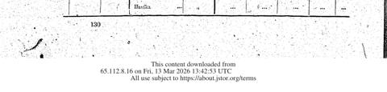

section(roman top)=32 · top=xxxii(roman) · bottom=130(arabic) · data_table

593f1f6d97df0406bb59e395ac28be26016c30bf.png

p.182 volume (arabic, bottom) was 84 → 182

TOP

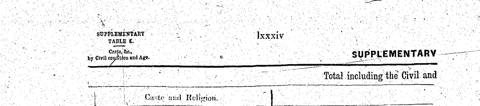

BOTTOM

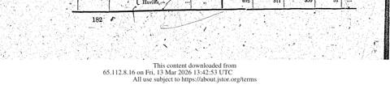

section(roman top)=84 · top=lxxxiv(roman) · bottom=182(arabic) · data_table

67ef10b4a6c71ec3b7089bb9bf6c8035e2d99d05.png

p.174 volume (arabic, bottom) was 76 → 174

TOP

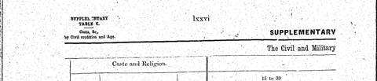

BOTTOM

[figure not shown]

section(roman top)=76 · top=lxxvi(roman) · bottom=174(arabic) · data_table

67b0cd245139e88892533a277352de8e3cbd989c.png

p.389 volume (arabic, bottom) was 73 → 389

TOP

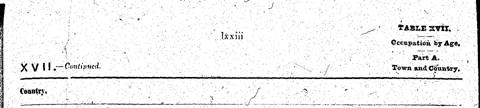

BOTTOM

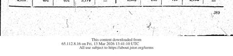

section(roman top)=73 · top=lxxiii(roman) · bottom=389(arabic) · data_table

6b5d2bad2484817c781cb2c14168f8f6f09adc0b.png

TOP

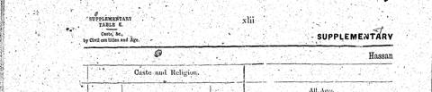

BOTTOM

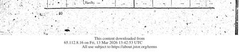

5fe89568df100a5c9322ade5b0d6a40e16989371.png

p.124 volume (arabic, bottom) was 26 → 124

TOP

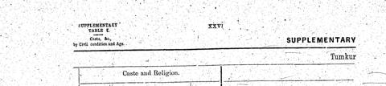

BOTTOM

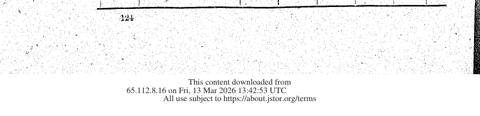

section(roman top)=26 · top=XXVI(roman) · bottom=124(arabic) · data_table

596152b6442c70e70590f02e729665320e626656.png

p.458 volume (arabic, bottom) was 44 → 458

TOP

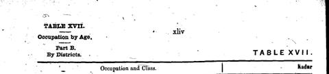

BOTTOM

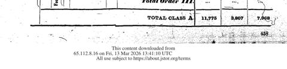

6714a725472f540ab9246ef7ba14da695a6ad2b0.png

p.323 volume (arabic, bottom) was 7 → 323

TOP

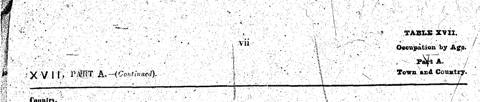

BOTTOM

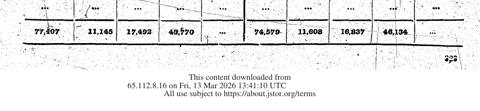

section(roman top)=7 · top=vii(roman) · bottom=323(arabic) · data_table

6e140511c6bccb5a987072ed4783ff4157fcfa78.png

p.114 volume (arabic, bottom) was 62 → 114

TOP

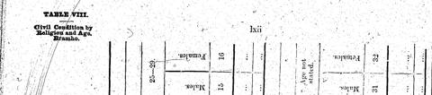

BOTTOM

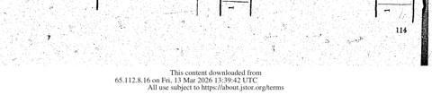

section(roman top)=62 · top=lxii(roman) · bottom=114(arabic) · data_table

7118eef5e483bb26c3d6d6312270a398397c664e.png

p.384 volume (arabic, bottom) was 68 → 384

TOP

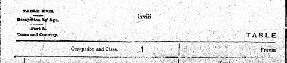

BOTTOM

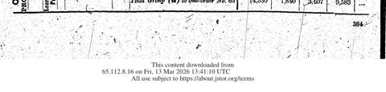

section(roman top)=68 · top=lxviii(roman) · bottom=384(arabic) · data_table

6cb89e22b435a8f7dc97000fd55dd6db99c558d3.png

p.393 volume (arabic, bottom) was 77 → 393

TOP

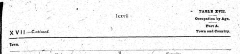

BOTTOM

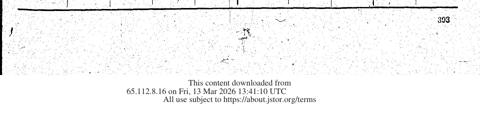

section(roman top)=77 · top=lxxvii(roman) · bottom=393(arabic) · data_table

7534dae45d3bb41a402cdcede0302440846e83bd.png

p.380 volume (arabic, bottom) was 64 → 380

TOP

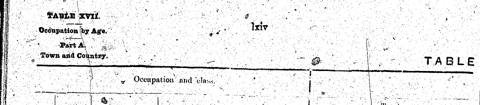

BOTTOM

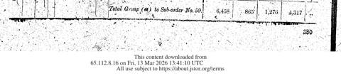

section(roman top)=64 · top=lxiv(roman) · bottom=380(arabic) · data_table

77e9b3f92d150db688d61ab7dffb9e5fc21c4268.png

p.330 volume (arabic, bottom) was 14 → 330

TOP

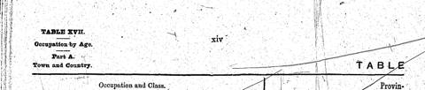

BOTTOM

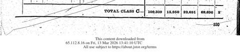

section(roman top)=14 · top=xiv(roman) · bottom=330(arabic) · data_table

7a939424f75b13be5aadc41de72b072f154c8773.png

p.408 volume (arabic, bottom) was 92 → 408

TOP

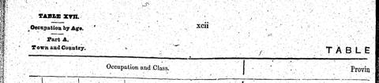

BOTTOM

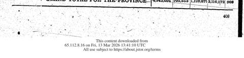

section(roman top)=92 · top=xcii(roman) · bottom=408(arabic) · data_table

7aa0e3b22a7388a4ae283f63528b14b6a51b3378.png

p.537 volume (arabic, bottom) was 123 → 537

TOP

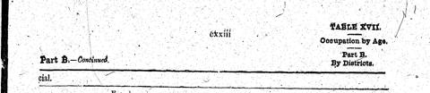

BOTTOM

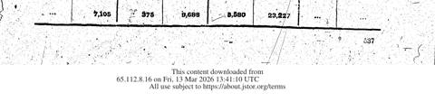

section(roman top)=123 · top=cxxiii(roman) · bottom=537(arabic) · data_table

86b74a4513806edc690632b3077fb6206ba95ccd.png

p.390 volume (arabic, bottom) was 74 → 390

TOP

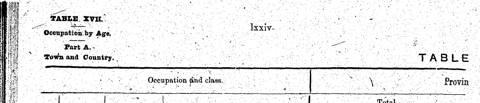

BOTTOM

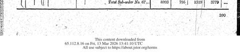

section(roman top)=74 · top=lxxiv(roman) · bottom=390(arabic) · data_table

813a72959b61996c60d6922e40f88e7ed717e086.png

p.105 volume (arabic, bottom) was 53 → 105

TOP

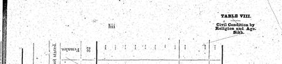

BOTTOM

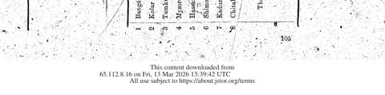

section(roman top)=53 · top=liii(roman) · bottom=105(arabic) · data_table

8769297ecef6df0b8d876d51f148588e793dbf60.png

p.382 volume (arabic, bottom) was 66 → 382

TOP

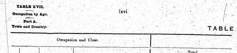

BOTTOM

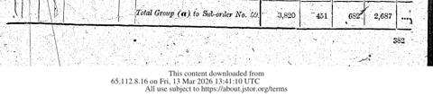

section(roman top)=66 · top=lxvi(roman) · bottom=382(arabic) · data_table

8855328b7259d788ad95a6072e493c58059b2855.png

p.337 volume (arabic, bottom) was 21 → 337